# Pertemuan 3 - Regresi dengan Peubah Lag

Rafael Dominico Prasetyo

2026-09-06

```r
library(dLagM)
library(dynlm)
library(MLmetrics)
library(lmtest)
library(readr)
```

# Import data

```r
data_aqi <-read.csv("C:\\Users\\Rafael Dominico\\Pictures\\Kuliah\\Semester 5\\Metode Peramalan Deret Waktu\\4\\NewDelhi_Air_quality.csv")
head(data_aqi)
```

```
##   X  AQI       CO      datetime        no2       o3      pm10     pm25
## 1 0 30.2 198.6027 2022-10-21:18 0.04685717 55.78995 10.486722 5.637410
## 2 1 28.2 197.6013 2022-10-21:19 0.04645554 54.93164 10.719325 4.618169
## 3 2 26.6 198.6027 2022-10-21:20 0.04685717 54.64554 11.155578 3.520902
## 4 3 25.0 201.9405 2022-10-21:21 0.04819594 55.07469 11.116206 2.225919
## 5 4 26.0 205.2784 2022-10-21:22 0.04886533 55.78995 10.405250 1.979471
## 6 5 26.0 208.6163 2022-10-21:23 0.05020411 56.50520  9.402518 1.792677
##         so2     timestamp_local       timestamp_utc         ts
## 1 0.3874302 2022-10-21T23:00:00 2022-10-21T18:00:00 1666375200
## 2 0.4097819 2022-10-22T00:00:00 2022-10-21T19:00:00 1666378800
## 3 0.4023313 2022-10-22T01:00:00 2022-10-21T20:00:00 1666382400
## 4 0.3762543 2022-10-22T02:00:00 2022-10-21T21:00:00 1666386000
## 5 0.3390014 2022-10-22T03:00:00 2022-10-21T22:00:00 1666389600
## 6 0.3129244 2022-10-22T04:00:00 2022-10-21T23:00:00 1666393200
```

```r
train <-data_aqi[1:56,]
test <-data_aqi[57:71,]

train.ts <- ts(train)
test.ts <- ts(test)
data.ts <- ts(data_aqi)
```

# Model Koyck

Model Koyck mengatasi masalah infinite distributed lag (pengaruh masa lalu yang tak terhingga) dengan mengasumsikan bahwa semakin jauh jarak lag, semakin kecil pengaruhnya.

Melalui transformasi aljabar, efek masa lalu dari X yang sangat panjang diringkas ke dalam satu variabel saja, yaitu Yt−1 . Bentuk persamaannya menjadi:

$Y_t = a(1-\lambda) + \beta_0 X_t + \lambda Y_{t-1} + V_t$

## Pemodelan

```r
model.koyck <- koyckDlm(x = train$CO, y = train$AQI)
summary(model.koyck)
```

```
##
## Call:
## "Y ~ (Intercept) + Y.1 + X.t"
##
## Residuals:
##      Min       1Q   Median       3Q      Max
## -2.03230 -0.56415  0.04037  0.59617  2.27331
##
## Coefficients:
##              Estimate Std. Error t value Pr(>|t|)
## (Intercept)  3.878159   9.674588   0.401    0.690
## Y.1          0.898129   0.082961  10.826 6.25e-15 ***
## X.t         -0.005832   0.055274  -0.106    0.916
## ---
## Signif. codes:  0 '***' 0.001 '**' 0.01 '*' 0.05 '.' 0.1 ' ' 1
##
## Residual standard error: 0.9327 on 52 degrees of freedom
## Multiple R-Squared: 0.8172,  Adjusted R-squared: 0.8102
## Wald test: 116.5 on 2 and 52 DF,  p-value: < 2.2e-16
##
## Diagnostic tests:
## NULL
##
##                             alpha         beta       phi
## Geometric coefficients:  38.06915 -0.005832077 0.8981286
```

Model Koyck menunjukkan bahwa variabel COtidak memiliki pengaruh signifikan terhadap AQI dalam jangka pendek dengan koefisien -0.005832. Hasil p-value = 0.916>0.05 yang menunjukkan variabel CO tidak signifikan. Adjusted R-squared menunjukkan 0.8102(81%) yang berarti model koyck dapat menjelasakan variabel AQI sebesar 81%.

## Peramalan

```r
fore.koyck <- forecast(model = model.koyck, x = test$CO, h = 15)
fore.koyck
```

```
## $forecasts
##  [1] 26.07124 26.13521 26.20241 26.28222 26.35391 26.42803 26.49459 26.55438
##  [9] 26.60807 26.65629 26.69960 26.72877 26.74523 26.75028 26.74509
##
## $call
## forecast.koyckDlm(model = model.koyck, x = test$CO, h = 15)
##
## attr(,"class")
## [1] "forecast.koyckDlm" "dLagM"
```

## Cek akurasi MAPE

```r
mape.koyck <- MAPE(fore.koyck$forecasts, test$AQI)
cat("MAPE Model Koyck:", mape.koyck, "\n")
```

```
## MAPE Model Koyck: 0.2151978
```

# Regression with Distributed Lag (DLM)

Berbeda dengan Koyck, pemodelan DLM membatasi secara spesifik berapa periode memori masa lalu yang dilibatkan. Batasan ini direpresentasikan dengan parameter q.

$Y_t = \alpha + \beta_0 X_t + \beta_1 X_{t-1} + \dots + \beta_q X_{t-q} + e_t$

```r
model.dlm <- dlm(x = train$CO, y = train$AQI, q = 2)
summary(model.dlm)
```

```
##
## Call:
## lm(formula = model.formula, data = design)
##
## Residuals:
##     Min      1Q  Median      3Q     Max
## -4.3189 -0.6906  0.3129  0.9539  3.5837
##
## Coefficients:
##              Estimate Std. Error t value Pr(>|t|)
## (Intercept) -49.37986   14.44776  -3.418  0.00126 **
## x.t           0.43780    0.16585   2.640  0.01104 *
## x.1          -0.02791    0.26860  -0.104  0.91766
## x.2          -0.03043    0.16493  -0.185  0.85435
## ---
## Signif. codes:  0 '***' 0.001 '**' 0.01 '*' 0.05 '.' 0.1 ' ' 1
##
## Residual standard error: 1.644 on 50 degrees of freedom
## Multiple R-squared:  0.4516, Adjusted R-squared:  0.4187
## F-statistic: 13.72 on 3 and 50 DF,  p-value: 1.183e-06
##
## AIC and BIC values for the model:
##        AIC      BIC
## 1 212.7899 222.7348
```

Pada model DLM, variabel CO saat ini (x.t) signifikan, sedangkan lag 1 (x.1) dan lag 2 (x.2) tidak signifikan. Hasil adjusted R-squared menunjukkan 41.87%.

## Penentuan Lag Optimum

```r
finiteDLMauto(formula = AQI ~ CO,
              data = data.frame(train), q.min = 1, q.max = 10,
              model.type = "dlm", error.type = "AIC", trace = TRUE)
```

[output not shown]

## Penentuan Lag Optimum

```r
finiteDLMauto(formula = AQI ~ CO,
              data = data.frame(train), q.min = 1, q.max = 10,
              model.type = "dlm", error.type = "AIC", trace = TRUE)
```

```
##    q - k    MASE      AIC      BIC    GMRAE     MBRAE R.Adj.Sq    Ljung-Box
## 10    10 0.79577 107.5879 131.3602 34179.77   0.48688  0.89140 6.480797e-05
## 9      9 0.80729 110.7004 132.9022 27214.14   0.37401  0.89186 2.600716e-04
## 8      8 0.97916 138.2263 158.8095 25075.14   4.20497  0.82622 1.145385e-02
## 7      7 1.28834 167.6407 186.5590 28248.91  -7.14257  0.70365 2.087143e-03
## 6      6 1.43471 186.6635 203.8717 21605.51   2.59245  0.58148 1.470245e-05
## 5      5 1.66229 199.8604 215.3150 34745.46   2.35009  0.47923 5.189162e-08
## 4      4 1.88095 207.5026 221.1613 44155.26   1.38434  0.42189 3.868531e-09
## 3      3 1.98503 211.7984 223.6202 46817.82   2.11033  0.40759 1.384591e-10
## 2      2 1.88754 212.7899 222.7348 37010.85 186.31783  0.41867 2.529951e-10
## 1      1 1.87673 216.3341 224.3634 29673.57   0.87152  0.40324 7.820683e-10
```

```r
# Bangun ulang model
model.dlm <- dlm(x = train$CO, y = train$AQI, q = 1)
summary(model.dlm)
```

```
##
## Call:
## lm(formula = model.formula, data = design)
##
## Residuals:
##     Min      1Q  Median      3Q     Max
## -4.3229 -0.7434  0.3267  0.9466  3.5719
##
## Coefficients:
##              Estimate Std. Error t value Pr(>|t|)
## (Intercept) -47.72317   12.75056  -3.743 0.000456 ***
## x.t           0.43451    0.12905   3.367 0.001436 **
## x.1          -0.06303    0.12905  -0.488 0.627312
## ---
## Signif. codes:  0 '***' 0.001 '**' 0.01 '*' 0.05 '.' 0.1 ' ' 1
##
## Residual standard error: 1.654 on 52 degrees of freedom
## Multiple R-squared:  0.4253, Adjusted R-squared:  0.4032
## F-statistic: 19.24 on 2 and 52 DF,  p-value: 5.555e-07
##
## AIC and BIC values for the model:
##        AIC      BIC
## 1 216.3341 224.3634
```

```r
# Peramalan model DLM Optimum
fore.dlm.opt <- forecast(model = model.dlm, x = test$CO, h = 15)
mape.dlm.opt <- MAPE(fore.dlm.opt$forecasts, test$AQI)
cat("MAPE Model DLM Optimum:", mape.dlm.opt, "\n")
```

```
## MAPE Model DLM Optimum: 0.1261175
```

Tingkat kesalahan MAPE adalah 0.126 (12.6%)

# Autoregressive Distributed Lag (ARDL)

```r
# Model ARDL dengan lag X = 1 dan lag Y = 1
model.ardl <- ardlDlm(formula = AQI ~ CO, data = train, p = 1, q = 1)
summary(model.ardl)
```

```
##
## Time series regression with "ts" data:
## Start = 2, End = 56
##
## Call:
## dynlm(formula = as.formula(model.text), data = data)
##
## Residuals:
##      Min       1Q   Median       3Q      Max
## -2.26671 -0.43299  0.09425  0.46991  1.88478
##
## Coefficients:
##             Estimate Std. Error t value Pr(>|t|)
## (Intercept) -4.53643    7.43963  -0.610  0.54472
## CO.t         0.23063    0.06822   3.381  0.00139 **
## CO.1        -0.18675    0.06690  -2.792  0.00736 **
## AQI.1        0.83905    0.06917  12.129  < 2e-16 ***
## ---
## Signif. codes:  0 '***' 0.001 '**' 0.01 '*' 0.05 '.' 0.1 ' ' 1
##
## Residual standard error: 0.8472 on 51 degrees of freedom
## Multiple R-squared:  0.8521, Adjusted R-squared:  0.8434
## F-statistic: 97.92 on 3 and 51 DF,  p-value: < 2.2e-16
```

Hasil model ARDL menunjukkan nilai variabel CO saat ini dan nilai CO 1 periode sebelumnya berpengaruh pada nilai AQI. Begitu juga dengan nilai variabel AQI periode sebelumnya berpengaruh pada nilai AQI saat ini.

## Lag Optimum ARDL

```r
model.ardl.opt <- ardlBoundOrders(data = data.frame(data_aqi), ic = "AIC", formula = AQI ~ CO)

# Menarik kombinasi lag dengan AIC terkecil
min_p <- c()
for(i in 1:6){
  min_p[i] <- min(model.ardl.opt$Stat.table[[i]])
}
q_opt <- which(min_p == min(min_p, na.rm = TRUE))
p_opt <- which(model.ardl.opt$Stat.table[[q_opt]] == min(model.ardl.opt$Stat.table[[q_opt]], na.rm = TRUE))

data.frame("Lag_Y_opt(q)" = q_opt, "Lag_X_opt(p)" = p_opt, "AIC" = model.ardl.opt$min.Stat)
```

```
##   Lag_Y_opt.q. Lag_X_opt.p.      AIC
## 1            6           15 121.7055
```

```r
# Peramalan ARDL awal (p=1, q=1)
fore.ardl <- forecast(model = model.ardl, x = test$CO, h = 15)
mape.ardl <- MAPE(fore.ardl$forecasts, test$AQI)
cat("MAPE Model ARDL (1,1):", mape.ardl, "\n")
```

```
## MAPE Model ARDL (1,1): 0.1482666
```

Tingkat kesalahan MAPE model ini mencapai 0.148(14.8%)

# Pendekatan dengan Library dynlm dan Uji Asumsi

```r
# Sama dengan DLM (q=1)
cons_lm1 <- dynlm(AQI ~ CO + L(CO), data = train.ts)

# Setara dengan Model Autoregressive Murni (Hanya melibatkan Xt dan Yt-1)
cons_lm2 <- dynlm(AQI ~ CO + L(AQI), data = train.ts)

# Sama dengan ARDL (p=1, q=1)
cons_lm3 <- dynlm(AQI ~ CO + L(CO) + L(AQI), data = train.ts)
```

# Uji Asumsi Model (Contoh pada cons_lm1)

## 1. Uji Autokorelasi (Durbin-Watson)

H0: Tidak ada autokorelasi

```r
dwtest(cons_lm1)
```

```
##
##  Durbin-Watson test
##
## data:  cons_lm1
## DW = 0.3392, p-value < 2.2e-16
## alternative hypothesis: true autocorrelation is greater than 0
```

## 2. Uji Heteroskedastisitas (Breusch-Pagan)

H0: Ragam sisaan homogen

```r
bptest(cons_lm1)
```

```
##
##  studentized Breusch-Pagan test
##
## data:  cons_lm1
## BP = 13.26, df = 2, p-value = 0.00132
```

## 3. Uji Normalitas (Shapiro-Wilk)

H0: Sisaan berdistribusi normal

```r
shapiro.test(residuals(cons_lm1))
```

```
##
##  Shapiro-Wilk normality test
##
## data:  residuals(cons_lm1)
## W = 0.94727, p-value = 0.01746
```

# Perbandingan Performa Model

```r
akurasi <- matrix(c(mape.koyck, mape.dlm.opt, mape.ardl))
row.names(akurasi) <- c("Koyck", "DLM Optimum", "ARDL (1,1)")
colnames(akurasi) <- c("MAPE")
print(akurasi)
```

```
##                  MAPE
## Koyck       0.2151978
## DLM Optimum 0.1261175
## ARDL (1,1)  0.1482666
```

# Visualisasi Aktual vs Peramalan

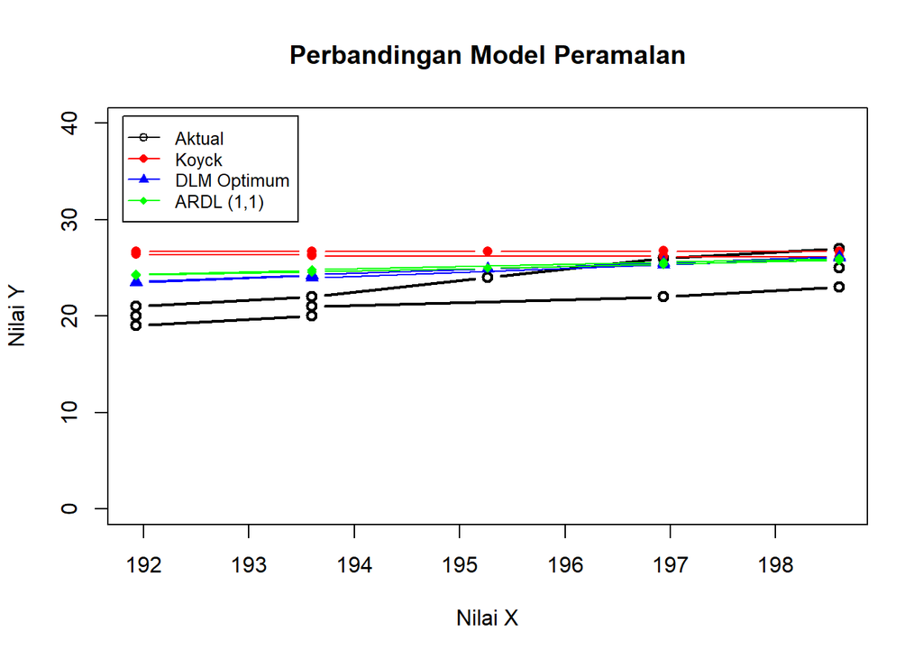

```r
par(mfrow=c(1,1))
plot(test$CO, test$AQI, type="b", col="black", ylim=c(0,40), lwd=2,
     ylab="Nilai Y", xlab="Nilai X", main="Perbandingan Model Peramalan")

lines(test$CO, fore.koyck$forecasts, col="red", type="b", pch=16)
lines(test$CO, fore.dlm.opt$forecasts, col="blue", type="b", pch=17)
lines(test$CO, fore.ardl$forecasts, col="green", type="b", pch=18)

legend("topleft", legend=c("Aktual", "Koyck", "DLM Optimum", "ARDL (1,1)"),
       col=c("black","red","blue","green"), lty=1, pch=c(1,16,17,18), cex=0.8, inset=0.02)
```

Garis merah (Koyck) tampak lebih melandai dan menjauhi data aktual sesuai dengan nilai MAPE-nya yang tertinggi (21.52%).

Garis biru (DLM) dan hijau (ARDL) berada lebih dekat dengan pola garis hitam. Garis biru (DLM) secara visual umumnya menjadi yang paling mendekati titik-titik aktual.